# Project Image Recognition 🍎 🍌 🥝

## Target ✅

To develop an image recognition algorithm that can accurately identify the type of fruit in an image

The model will be able to recognize all 60 types of fruits in the dataset 🤹🏼‍♀️

## Help to speed up the checkout process 🍡

The system will automatically identify the type of fruit

Reduce wait times

Improve the shopping experience for customers 📈

## 🍅 Help to reduce errors

The system can accurately identify the fruit

Possibility of human error

## 🥥 Improve inventory management

Track the sales of each type of fruit

Provide valuable data to the store owner 📔

Better decisions about inventory levels and product ordering

## I know my data 🤓 💻

**Considering we will working with image recognition it's better to have some pictures**

Fruits 360 is

60 different fruits with multiple images for each 🍏🍎🍐🍊🍋🍌🍉🍇🍓🍈🍒🍑🍍🥥🥝🍅

Perfect to have fun 🤩

[figure not shown]

## Features 🍊

- Each fruit image has a resolution of 100x100 pixels ( JPG format )
- Labels for each fruit image, indicating the type of fruit

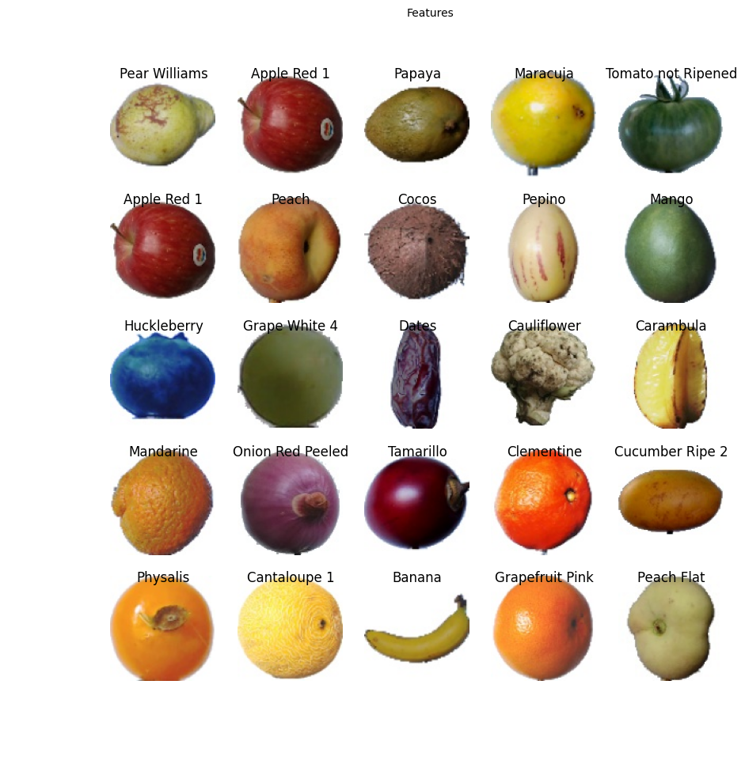

## Number of classes

131 different fruit classes in the dataset, which means that there are 60 different types of fruits

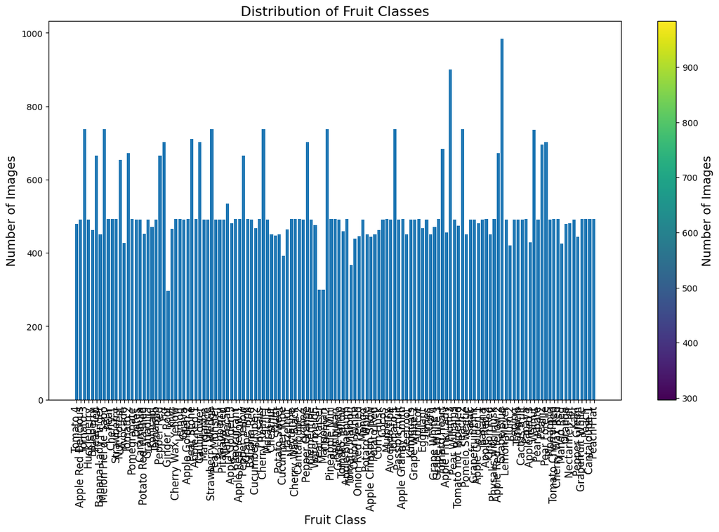

## 🍒 Number of objects per class

The number of objects per class varies depending on the fruit type. Some fruits have more images in the dataset than others. For example, there are over 984 images of Grape Blue 🍇 , while there are only around 492 images of apricots.

## Range 🍌🍌

The range of the target variable is determined by the number of classes in the dataset, which is 131.

The target variable is a categorical variable ( 131 possible values ) each corresponding to a different fruit class. The values of the target variable are represented as integers in the range of 0 to 130 ( indices of the class labels in the list of class names )

For example ➡️ if the class names are stored in a list called class_names, the target variable for an apple image would be 0, while the target variable for a banana image would be 15, assuming that the class name "apple" has index 0 and the class name "banana" has index 15 in the class_names list.

## 🥧 Limits

One potential limit of this dataset is that it only includes images of fruits, which means that the image recognition model trained on this dataset may not perform as well on images of other objects.

Finally, the resolution of the images may not be sufficient for some applications, depending on the use case.